# stars/sf training

Edzer Pebesma

8/18/2020

## Downloading data

```r
download.file("https://opengeohub.org/spcg2020_train_data.rds",
                            "spg2020_train_data.rds")
download.file("https://opengeohub.org/spcg2020_validate_data.rds",
                            "spcg2020_validate_data.rds")
```

## Read data:

```r
train = readRDS("spg2020_train_data.rds")
head(train)
```

```
##   day month   id        long      lat     time UID.y year radiation
## 1  15     2 3732   -0.038889 43.09694 14:00:00    EU 2017  3.547418
## 2  28     5 1645  100.217000 25.58100 14:00:00    CN 2017  4.477507
## 3  11     8 3732   -0.038889 43.09694 18:00:00    EU 2017  3.547418
## 4  14     6 5943 -104.262726 32.38012 15:00:00    US 2017  5.666179
## 5   2    11 4184   -0.068218 51.59930 01:00:00    EU 2017  2.800000
## 6  11     4 4184   -0.068218 51.59930 13:00:00    EU 2017  2.800000
##   nightlight_450 nightlight_4950 nightlight_3150 nightlight_900  elevation
## 1      38.675789        3.891474        8.516371      33.357311  399.63635
## 2      30.628765       12.111422       17.736227      28.639259 1986.53503
## 3      38.675789        3.891474        8.516371      33.357311  399.63635
## 4       1.880603        7.635683        5.534259       1.692239  975.70282
## 5      70.840591       35.605587       38.306770      59.728512   15.18045
## 6      70.840591       35.605587       38.306770      59.728512   15.18045
##   industry_1000 industry_100 industry_25 industry_3000 industry_300
```

[output cut: 83 more lines]

```r
validate = readRDS("spcg2020_validate_data.rds")
head(validate)
```

```
##   day month   id      long       lat     time UID.y year radiation
## 1   5     6   75 -55.19852  47.09899 06:00:00    CA 2017  3.143478
## 2  22    12   25 152.77391 -27.65285 21:00:00    AU 2017  4.948618
## 3  27     7   80 -63.57366  44.64711 00:00:00    CA 2017  3.530465
## 4   8    11   53 152.99340 -27.53578 08:00:00    AU 2017  4.887681
## 5   2    11 6044 -95.29472  29.68639 00:00:00    US 2017  4.716000
## 6  25     8 2105  37.57529  55.53683 22:00:00   oaq 2017  2.930000
##   nightlight_450 nightlight_4950 nightlight_3150 nightlight_900  elevation
## 1       5.435541        0.559907        1.036655       4.237725   3.290054
## 2       7.979826        6.144553        5.458912       7.006218  57.938126
## 3      82.829300       31.703270       38.475060      70.335953  24.721416
## 4      26.224216       16.934456       18.091354      25.813087   8.360867
## 5      50.758938       52.200005       53.348137      56.233345  12.864291
## 6      91.483826       68.156044       71.543701      85.315254 179.371872
##   industry_1000 industry_100 industry_25 industry_3000 industry_300
```

[output cut: 83 more lines]

```r
setdiff(names(train), names(validate)) # name of the target variable
```

```
## [1] "value_g"
```

## Handle date and time (if you want)

```r
train$t = paste(train$date, train$time)
head(train$t)
```

```
## [1] "2017-02-15 14:00:00" "2017-05-28 14:00:00" "2017-08-11 18:00:00"
## [4] "2017-06-14 15:00:00" "2017-11-02 01:00:00" "2017-04-11 13:00:00"
```

```r
train$t = strptime(train$t, format = "%Y-%m-%d %H:%M:%S", tz="UTC")
head(train$t)
```

```
## [1] "2017-02-15 14:00:00 UTC" "2017-05-28 14:00:00 UTC"
## [3] "2017-08-11 18:00:00 UTC" "2017-06-14 15:00:00 UTC"
## [5] "2017-11-02 01:00:00 UTC" "2017-04-11 13:00:00 UTC"
```

```r
library(sf)
train_sf = st_as_sf(train, coords = c("long", "lat"), crs = 4326)
```

# Spacetime layout:

What is the table size anyway?

```r
dim(train)
```

```
## [1] 11731    66
```

how many unique time steps do we have? What is their range?

```r
length(unique(train$t))
```

```
## [1] 6497
```

```r
range(train$t)
```

```
## [1] "2017-01-01 00:00:00 UTC" "2017-12-31 23:00:00 UTC"
```

```r
24 * 356
```

```
## [1] 8544
```

What is the distribution of the time series? lenghts? Count how many points coincide with every individual point:

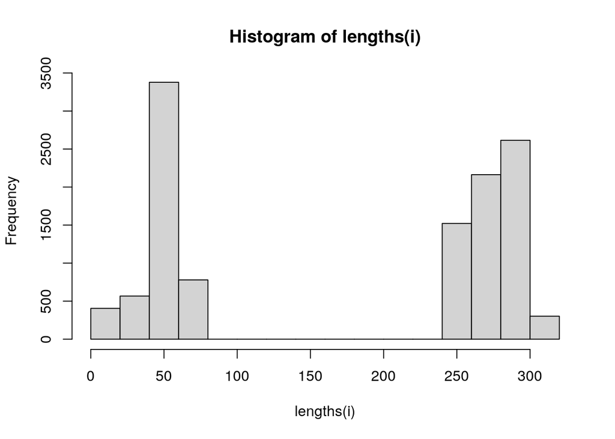

```r
i = st_intersects(train_sf)
hist(lengths(i))
```

How regular are the time steps?

```r
df = diff(sort(train$t))
range(df[df > 0])
```

```
## Time differences in secs
## [1]  3600 25200
```

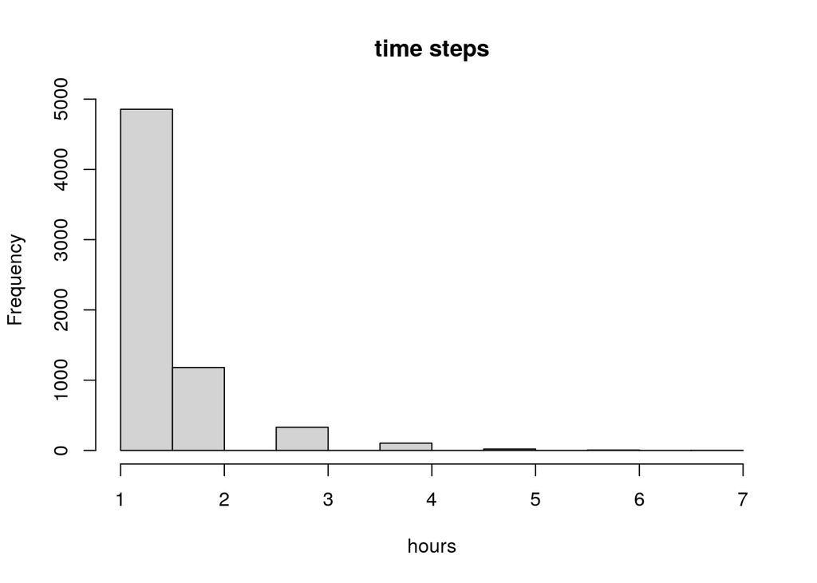

```r
df = as.numeric(df)
hist(df[df > 0] / 3600, xlab = "hours", main = "time steps")
```

## Finding unique points

```r
n = nrow(train)
duplicate = vector("logical", n)
for (x in 1:n) {
   eq = i[[x]]
   duplicate[eq[eq > x]] = TRUE
}
sum(!duplicate)
```

```
## [1] 152
```

# Check the unique points

```r
pts = st_geometry(train_sf)[!duplicate]
i2 = st_intersects(pts, train_sf)
length(unique(unlist(i2))) == length(unlist(i2)) # so all are unique
```

```
## [1] TRUE
```

# Space-time layout

```r
library(xts)
l = lapply(i2, function(x) xts(train_sf$value_g[x], train_sf$t[x]))
ts = do.call(cbind, l)
colnames(ts) = paste0("POINT", 1:ncol(ts))
head(ts[,1:10])
```

```
##                     POINT1 POINT2 POINT3 POINT4 POINT5 POINT6 POINT7 POINT8
## 2017-01-01 00:00:00     NA     NA     NA     NA     NA     NA     NA     NA
## 2017-01-01 01:00:00     NA     NA     NA     NA     NA     NA     NA     NA
## 2017-01-01 02:00:00     NA     NA     NA     NA     NA     NA     NA     NA
## 2017-01-01 03:00:00     NA     NA     NA     NA     NA     NA     NA     NA
## 2017-01-01 05:00:00     NA     NA     NA     NA     NA     NA     NA     NA
## 2017-01-01 06:00:00     NA     NA     NA     NA     NA     NA     NA     NA
##                     POINT9 POINT10
## 2017-01-01 00:00:00     NA      NA
## 2017-01-01 01:00:00     NA      NA
## 2017-01-01 02:00:00     NA      NA
## 2017-01-01 03:00:00     NA      NA
## 2017-01-01 05:00:00     NA      NA
## 2017-01-01 06:00:00     NA      NA
```

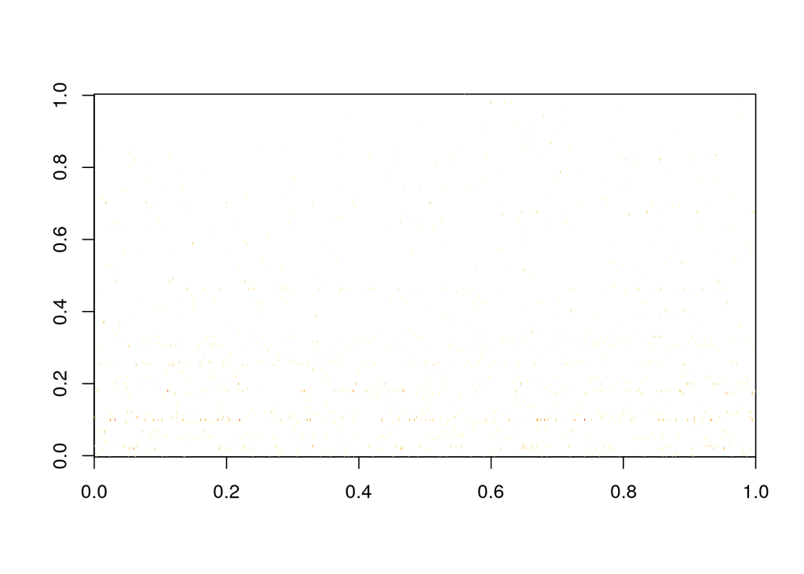

```r
image(as.matrix(ts))
```

What a mess!

## A simpler approach:

- assume we have daily data
- assume id identifies the station

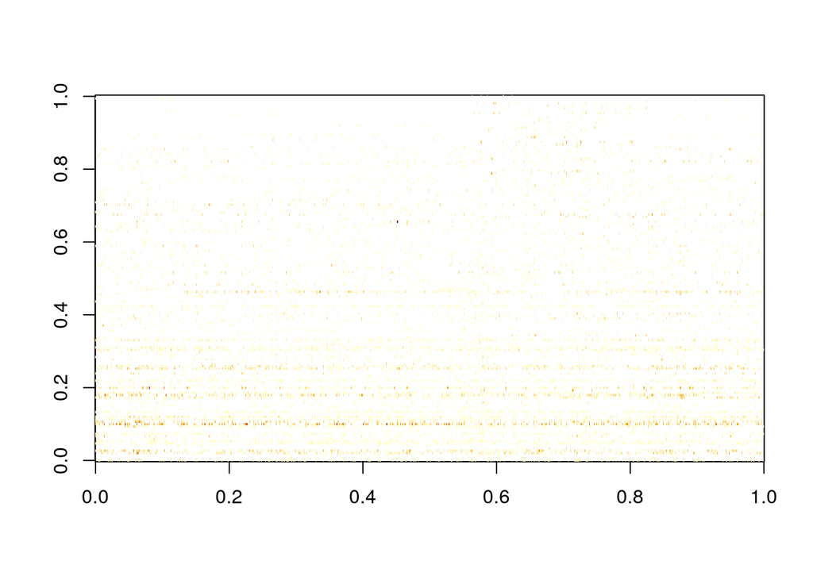

```r
ids = unique(train$id)
# make groups for each station:
l = lapply(ids, function(x)
        xts(train$value_g[train$id==x], train$date[train$id == x]))
im = do.call(cbind, l)
names(im) = paste0("VAR", ids)
image(as.matrix(im))
```

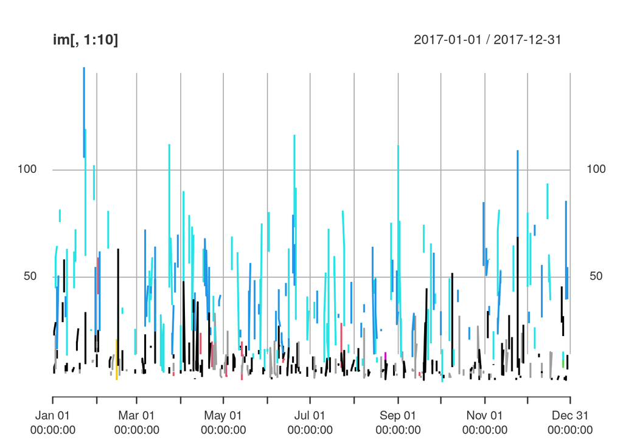

```r
plot(im[,1:10])
```

## Do we have validation points coinciding to the training points?

```r
unique(validate$id) %in% unique(train$id)
```

```
##  [1] FALSE FALSE FALSE FALSE FALSE FALSE FALSE FALSE FALSE FALSE FALSE FALSE
## [13] FALSE FALSE FALSE FALSE FALSE FALSE FALSE FALSE  TRUE FALSE FALSE FALSE
## [25] FALSE FALSE FALSE FALSE FALSE FALSE FALSE FALSE FALSE FALSE FALSE FALSE
## [37] FALSE FALSE FALSE FALSE FALSE FALSE FALSE FALSE FALSE FALSE FALSE FALSE
## [49] FALSE FALSE FALSE FALSE FALSE FALSE FALSE FALSE FALSE FALSE FALSE FALSE
## [61] FALSE FALSE FALSE FALSE FALSE FALSE FALSE FALSE FALSE FALSE FALSE FALSE
## [73] FALSE FALSE FALSE FALSE FALSE FALSE FALSE FALSE FALSE FALSE FALSE
```

```r
any(unique(validate$id) %in% unique(train$id))
```

```
## [1] TRUE
```

```r
which(unique(validate$id) %in% unique(train$id))
```

```
## [1] 21
```

```r
nrow(validate[validate$id == 41,])
```

```
## [1] 85
```

```r
nrow(validate)
```

```
## [1] 5844
```

```r
library(stars)
(st = st_as_stars(im))
```

```
## stars object with 2 dimensions and 1 attribute
## attribute(s):
##
##  Min.   :  0.10
##  1st Qu.:  5.30
##  Median : 12.20
##  Mean   : 21.13
##  3rd Qu.: 29.00
##  Max.   :240.00
##  NA's   :145589
## dimension(s):
##        from   to offset delta refsys point                    values
## time      1 1035     NA    NA   Date    NA 2017-01-01,...,2017-12-31
## others    1  152     NA    NA     NA    NA       VAR3732,...,VAR2162
```

## Add point features:

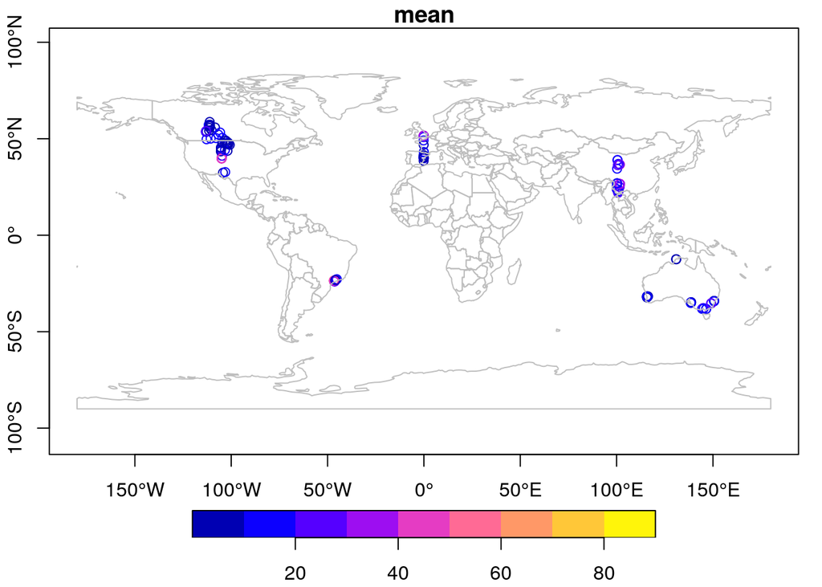

```r
l = lapply(ids, function(x)
        train_sf[train$id==x,][1,])
pts = st_geometry(do.call(rbind, l))
st_sf = st_set_dimensions(st, 2, values = pts)
library(rnaturalearth)
ne = ne_countries(returnclass = "sf")
st_means <- st_apply(st_sf, 2, mean, na.rm = TRUE) %>%
    st_as_sf()
plot(st_means, axes=TRUE, reset = FALSE, extent = ne)
plot(ne_countries(returnclass = "sf"), add = TRUE, col = NA, border = 'grey')
```

Where are the validation data, spatially?

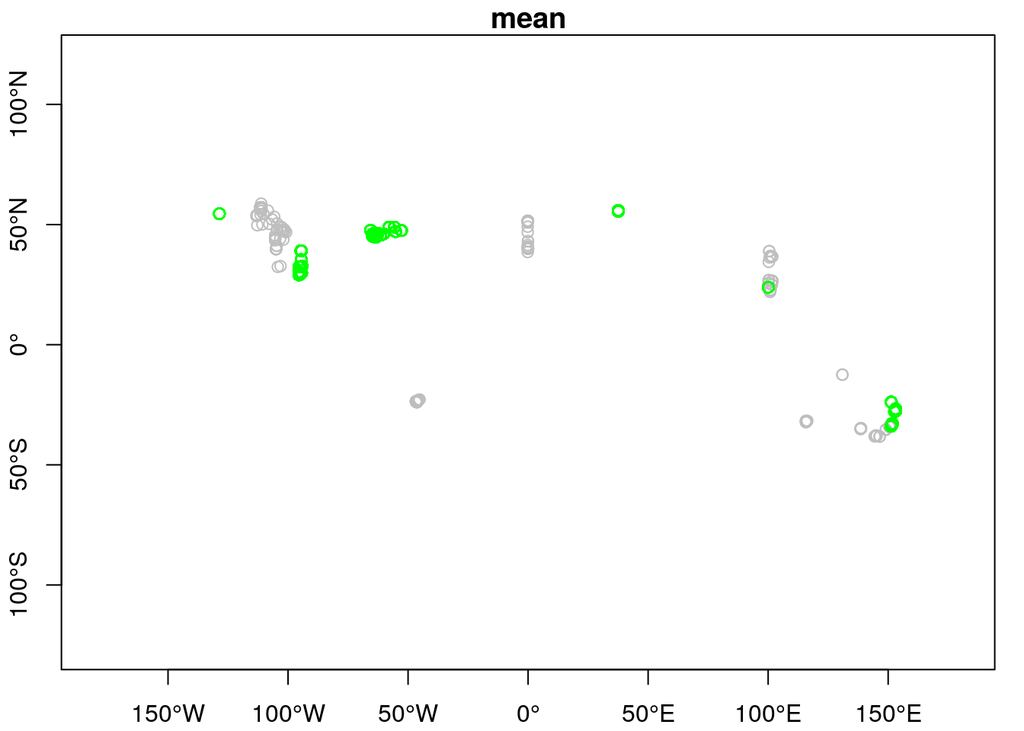

```r
plot(st_means, key.pos = NULL, col = 'grey', extent = ne, reset = FALSE,
         axes = TRUE)
val_sf = st_as_sf(validate, coords = c("long", "lat"), crs = 4326)
plot(val_sf, col = 'green', add = TRUE)
```

## Inverse distance weighted interpolation of means

At validation sites:

```r
library(gstat)
val_idw = idw(mean~1, st_means, val_sf)
```

```
## [inverse distance weighted interpolation]
```

At a regular grid:

```r
library(gstat)
sf_use_s2(FALSE)
idw_global = idw(mean~1, st_means, st_as_stars()[ne])
```

```
## although coordinates are longitude/latitude, st_intersects assumes that they are planar
```

```
## [inverse distance weighted interpolation]
```

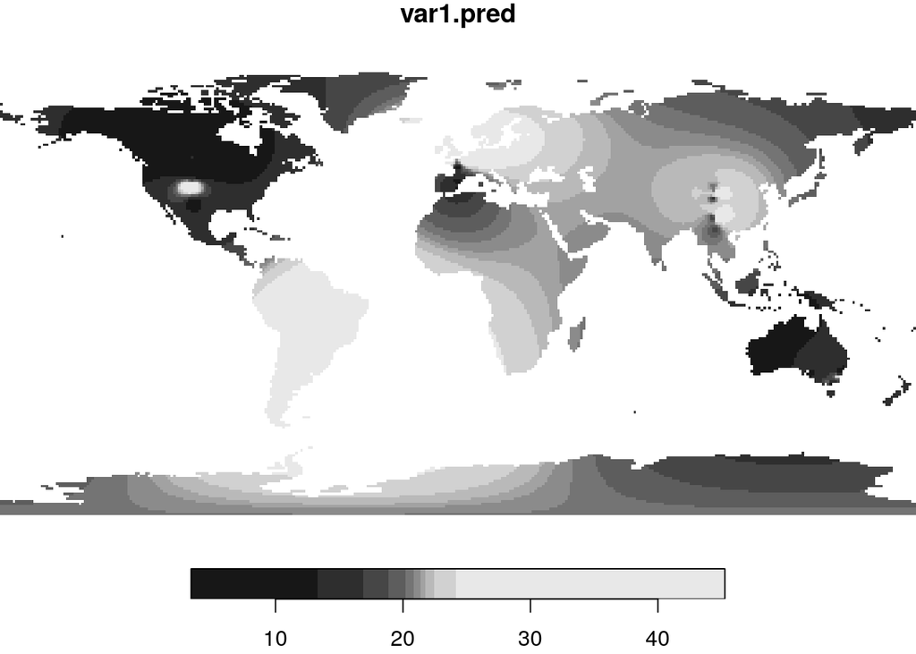

```r
plot(idw_global)
```

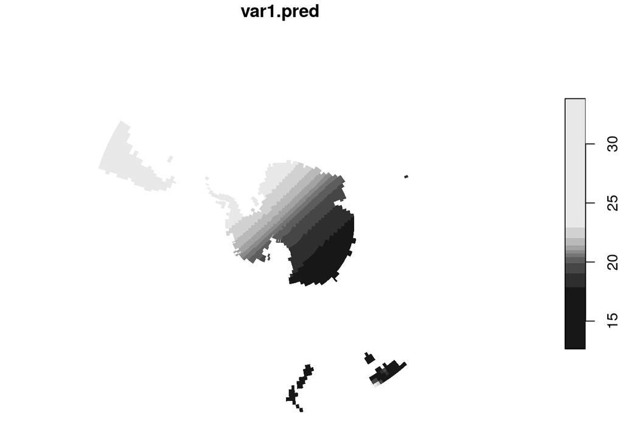

```r
plot(st_transform(idw_global[,,120:174], 3031))
```

# pointers to S2 in R:

- https://www.r-spatial.org/r/2020/06/17/s2.html
- https://cran.r-project.org/web/packages/sf/vignettes/sf7.html
- CRAN package s2: https://github.com/r-spatial/s2
- round is a better aproximation of the world’s shape, compared to flat.
- really: much, much better.
- legacy datasets might present some problems when thrown on the sphere.

# New PROJ:

- https://www.r-spatial.org/r/2020/03/17/wkt.html
- links therein

“+proj=longlat +datum=WGS84” “+init=epsg:4326”

- PROJ.4 strings are deprecated: stop using them
- WKT is a more complete representation of CRS
- WKT2 (GDAL >= 2.4 or so) is even better
- drops the pivot datum WGS84 for conversions and transformations
- adopts a large set of datum grids
- stronger support for 3D datums/transformations
- upcoming: supporting epochs and time-dependent CRS’s